# The ideal gas

The [ideal gas](https://en.wikipedia.org/wiki/Ideal_gas) is perhaps one of the most simplistic models of a physical system which actually describe real gases under special conditions (low densities, high temperatures).

$$pV=Nk_BT$$

where $N$ is the number of particles in the gas and $k_B$ is the Boltzmann constant. Our goal is to simulate this macroscopic behavior by a using a microscopic model for the ideal gas.

### Microscopic model

We want to put a bunch of noninteracting particles in a container, moving at constant speed and elastically colliding with the walls of the container. The probability distribution of the speed of each particle turns out to be the Maxwell-Boltzmann distribution. For a 2D gas (we are in two-dimensions in Pygame), take a look at [this](http://fab.cba.mit.edu/classes/864.11/people/dhaval_adjodah/final_project/write_up_boltzmann.pdf) for the derivation of the Maxwell-Bolztmann distribution in 2D. This turns out to be a chi distribution with 2 degrees of freedom (also known as Raileigh distribution) which is built-in in most statistical packages (for instance, the python numpy.random.rayleigh). The corresponding probability density function is

$$f_\sigma(v)=\dfrac{v}{\sigma^2}e^{-v^2/2\sigma^2}$$

where $v$ is the speed, and $\sigma^2=k_BT/m$, with $m$ being the mass of each particle. Here $\sigma$ plays the role of the scale parameter.

### Simulation

Using the microscopic model, we want to test Boyle’s law (keeping $T$ constant in the equation of state). That is, we want to compress our gas and measure pressure versus volume, plotting the result. Therefore, we want to compare with

$$p=\dfrac{mN\sigma^2}{h}$$

where $\sigma^2$ is a measure of the (fixed) temperature and $h$ the height of the closed container, which you should vary in the simulation. For a given number of particles $N$, we will choose values of $m$ that fit your data (this method can be improved).

Run the simulation by slowly varying the vertical position $h$ of the wall at the top (piston) from an initial value to a final value. The screen should show the process. Once the final value is reached you should have two arrays: all the values of pressure that you measure for each corresponding value of $h$. Look up how to plot (using python matplotlib) $h$ in the horizontal axis, $p$ in the vertical axis (your data), superimposed to the curve $p=mN\sigma^2/h$ (which you generate in the same plot and display with line, no points). This should go directly to a png file in your working directory, not to the screen, which is then read by Pygame (say as myplot = pygame.image.load(“file.png”) and placed on the screen (say as screen.blit(myplot, choose where)). Probably there is a better way to do this, but this ensures that the plot appears on the same screen as the Pygame simulation.

A sample plot:

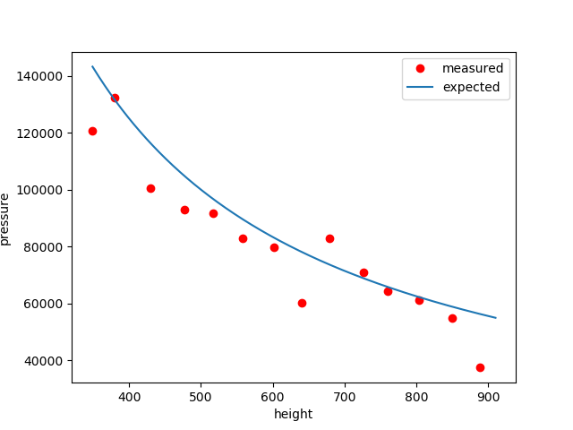

Boyle’s law